# Quiz Module 3

Saul Garcia

4/10/2017

```r
library(dplyr)
library(ggplot2)
library(statsr)
library(stats)
library(knitr)
```

1. For the Credit Scoring dataset (DATA_3.01_CREDIT.csv): using the same specifications as the examples covered during the videos, which of the following claims is correct? (You can select multiple answers.)

```r
# Read Data
data=read.table('../Data/DATA_3.01_CREDIT.csv',sep=',',header=TRUE)

# Linear Regression
linreg=lm(Rating~.,data=data)
index = (summary(linreg))$coefficients[,4]<.05

# Show only the significant variables with pvalue < 0.05
summary(linreg)$coefficients[index,]
```

```
               Estimate  Std. Error   t value      Pr(>|t|)
(Intercept) 140.8813773 9.666167105  14.57469  1.888058e-36
Income        2.0947030 0.048117688  43.53291 5.972507e-129
StudentYes  -98.8047783 4.959789058 -19.92117  3.574407e-56
Balance       0.2313633 0.003661448  63.18903 3.274386e-171
```

**Answer**

- The variable balance has a positive impact on the rating, everything else being equal
- Students have, everything else being equal, a weaker rating
- People with larger income have, everything else being equal, a better rating
2. For the Credit Scoring dataset (DATA_3.01_CREDIT.csv): if you estimate a linear regression of the credit score (Rating) with all the variables included in the dataset, i.e. the same specifications as used in the videos. What is the resulting estimated effect for the variables Income, Cards and Married?

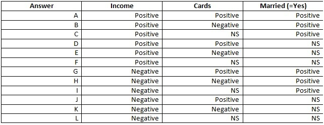

Table

With:

· **Positive** : as the variable increases, the expected credit score increases

· **Negative**: as the variable increases, the expected credit score decreases

· **NS**: the variable has no significant effect on the expected credit score. We consider an effect to be significant when the p-value is smaller than 0.05.

```r
names = c("Income","Cards","MarriedYes")
summary(linreg)$coefficients[names,]
```

```
##             Estimate Std. Error    t value      Pr(>|t|)
## Income      2.094703 0.04811769 43.5329105 5.972507e-129
## Cards      -0.762853 1.07987423 -0.7064276  4.804914e-01
## MarriedYes  3.176873 3.00553513  1.0570074  2.913910e-01
```

**Answer**

**F**: Positive, NS, NS

3. For the Credit Scoring dataset (DATA_3.01_CREDIT.csv): if you estimate a linear regression of the credit score (Rating) as a function of the variables Income, Cards and Married, what is the result of the estimation?

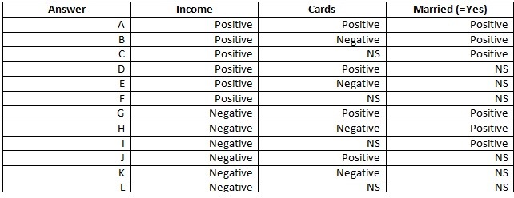

Table 2

```r
fit2 = lm(Rating~ Income +  Cards +  Married, data=data)
summary(fit2)
```

```
Call:
lm(formula = Rating ~ Income + Cards + Married, data = data)

Residuals:
    Min      1Q  Median      3Q     Max
-173.92  -77.36   -0.61   85.98  181.53

Coefficients:
            Estimate Std. Error t value Pr(>|t|)
(Intercept) 165.2144    16.6412   9.928   <2e-16 ***
Income        3.4196     0.1637  20.896   <2e-16 ***
Cards         8.2699     4.0988   2.018   0.0445 *
MarriedYes   11.8404    11.3387   1.044   0.2972
---
Signif. codes:  0 '***' 0.001 '**' 0.01 '*' 0.05 '.' 0.1 ' ' 1

Residual standard error: 95.71 on 296 degrees of freedom
Multiple R-squared:  0.6016,    Adjusted R-squared:  0.5975
F-statistic:   149 on 3 and 296 DF,  p-value: < 2.2e-16
```

Now the variable `Cards` becomes significant.

**Answer**

**D** POSITIVE, POSITIVE, NS

4. For the HR dataset (DATA_3.02_HR2.csv), adapt the code of the R script to change the cutoff so that an employee with a probability of leaving larger than .5 will be seen as likely to leave. Which one of the following is the resulting output?

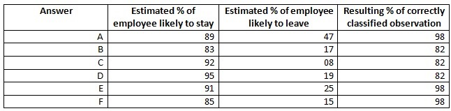

Table 3

```r
# Load Data
datatot=read.table('../Data/DATA_3.02_HR2.csv', header = T,sep=',')

# Generalized Linear Model: Estimate the drivers of attrition
logreg = glm(left ~ ., family=binomial(logit), data=datatot)

summary(logreg)
```

```
##
## Call:
## glm(formula = left ~ ., family = binomial(logit), data = datatot)
##
## Deviance Residuals:
##     Min       1Q   Median       3Q      Max
## -2.1727  -0.5410  -0.3535  -0.1994   3.0949
##
## Coefficients:
##               Estimate Std. Error z value Pr(>|z|)
## (Intercept) -1.2412448  0.1601334  -7.751 9.09e-15 ***
## S           -3.8163201  0.1207448 -31.607  < 2e-16 ***
## LPE          0.5044011  0.1809102   2.788   0.0053 **
## NP          -0.3591952  0.0264709 -13.569  < 2e-16 ***
## ANH          0.0037840  0.0006237   6.067 1.30e-09 ***
## TIC          0.6187913  0.0271161  22.820  < 2e-16 ***
## Newborn     -1.4851023  0.1128772 -13.157  < 2e-16 ***
## ---
## Signif. codes:  0 '***' 0.001 '**' 0.01 '*' 0.05 '.' 0.1 ' ' 1
##
## (Dispersion parameter for binomial family taken to be 1)
##
##     Null deviance: 10813.5  on 11999  degrees of freedom
## Residual deviance:  8508.9  on 11993  degrees of freedom
## AIC: 8522.9
##
## Number of Fisher Scoring iterations: 6
```

```r
cutoff=.5 #

# Percentage of correctly classified employees who stayed
a = sum((logreg$fitted.values<=cutoff)&(datatot$left==0))/sum(datatot$left==0)

# Compute the percentage of correctly classified employees who left
b = sum((logreg$fitted.values>cutoff)&(datatot$left==1))/sum(datatot$left==1)

# Compute the overall percentage of correctly classified employees
c = mean((logreg$fitted.values>cutoff)==(datatot$left==1))

kable(data.frame("LikelyStay"=a, "LikelyLeave" = b, "CorrectlyClassified" = c))
```

| LikelyStay | LikelyLeave | CorrectlyClassified |
| --- | --- | --- |
| 0.9464 | 0.1905 | 0.8204167 |

**Answer**

**D**

5. For the HR dataset (DATA_3.02_HR2.csv), using the same specifications as seen during the videos, which of the following claims is correct? (You can select multiple answers.)

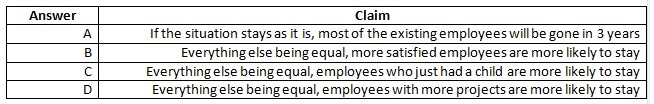

Table 4

**Answer** **B,C,D**